# Assignment 1 - exploratory analysis

Chris Snow

06/11/2016

# Overview

This report is an exploratory analysis of three data files containing blog, news and twitter data. This analysis is the first step in a project to build a predictive typing model that helps suggests words and spellings as users are typing text into a device such as a mobile phone.

This report contains only a high level summary of the exploratory analysis. For those interested in more information, the markdown source for this report can be found here: https://github.com/snowch/coursera_dsx_capstone/blob/master/coursework/assignment_1.Rmd

# Summary Statistics

In this section, we provide some summary statistics of the data.

## File statistics

We start with some statistics on the raw data files.

```
## [1] "  899288 37334690 210160014 ./final/en_US/en_US.blogs.txt"
```

```
## [1] " 1010242 34372720 205811889 ./final/en_US/en_US.news.txt"
```

```
## [1] " 2360148 30374206 167105338 ./final/en_US/en_US.twitter.txt"
```

The output is: number of lines, number of words, number of characters

## Processing the data

We Limit the number of docs from each source because the full dataset will require too much computing resource to process. To do this we stop after reading the first LIMIT_NUM_DOCS lines of each file. Note that an alternative approach may be to randomly sample lines rather than reading then all.

```r
LIMIT_NUM_DOCS <- 2000
```

## Wordcloud

It is useful to visualise the wordcloud for the data

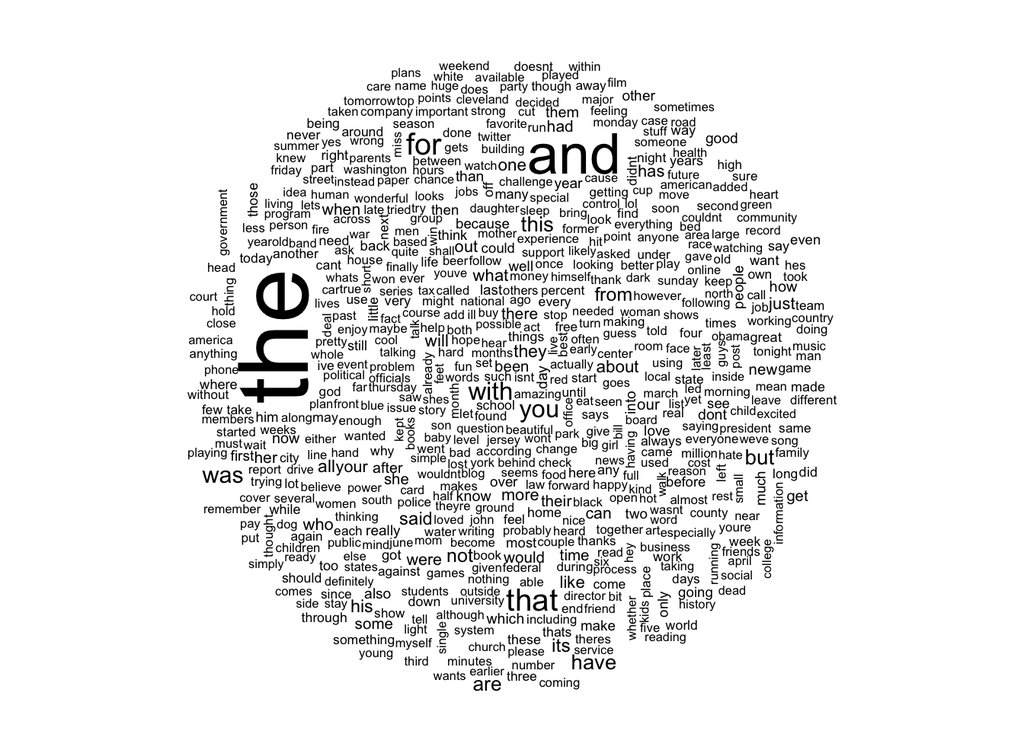

## N-Grams

### What are the frequencies of 2-grams?

The top 10 digrams in decending order

```
##          [,1]
## of the    793
## in the    745
## to the    376
## on the    337
## for the   330
## to be     325
## and the   244
## at the    230
## in a      226
## with the  211
```

### What are the frequencies of 3-grams?

The top 10 trigrams in decending order

```
##             [,1]
## a lot of      71
## one of the    64
## going to be   32
## it was a      26
## the end of    25
## to be a       25
## a couple of   24
## i want to     24
## be able to    23
## part of the   23
```

## Word count

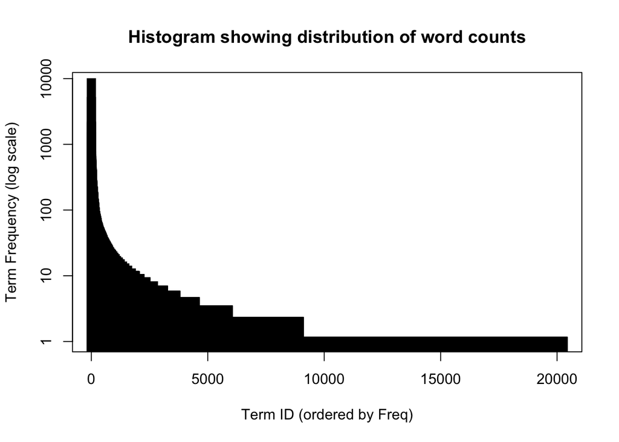

The above plot shows that a few terms have very high frequency, but over half of the terms only appear once in the corpus.

50% of corpus is covered by this number of unique words:

```
## [1] 310
```

90% of corpus is covered by this number of unique words:

```
## [1] 7811
```

## Non English words

Percentage of non-english words

```
## [1] 0.0148258
```

# Next Steps

The next steps of the project will be to decide how to create the prediction algorithm. One option will be to look at the bigram and trigam data to lookup the liklihood of the next term and suggesting the term with the strongest liklihood. This should be relatively easy to replicate by exporting the bigram and trigram data to a file where it can be re-used in the shiny app.